# Фінальний проект. Аналіз динаміки ДТП в Україні

2025-11-29

**Мета:** *Дослідити динаміку дорожньо-транспортних пригод (ДТП) в Україні за останні 10 років та перевірити гіпотези щодо стабільності показників у часі та просторі.*

**Завдання:**

- Вилучити актуальні дані про адміністративний устрій засобами Web Scraping.
- Проаналізувати часовий ряд кількості ДТП.
- Виявити регіональні диспропорції в аварійності.
- Візуалізувати результати засобами бібліотеки `ggplot2` та побудувати картограму.

## 1. Налаштування середовища

## 2. Збір даних (Web Scraping & Data Generation)

Для отримання актуального переліку адміністративних одиниць використано дані з відкритих джерел (Вікіпедія).

### 2.1. Скрапінг назв регіонів

Використаємо пакет `rvest` для отримання таблиці адміністративного поділу.

```r
url <- "https://uk.wikipedia.org/wiki/%D0%9E%D0%B1%D0%BB%D0%B0%D1%81%D1%82%D1%96_%D0%A3%D0%BA%D1%80%D0%B0%D1%97%D0%BD%D0%B8"

regions_table <- read_html(url) %>%
  html_nodes("table.wikitable") %>%
  .[[1]] %>%
  html_table(fill = TRUE)

regions_clean <- regions_table %>%
  select(Name = 1) %>%
  mutate(
    Name = str_remove(Name, " область"),
    Name = str_trim(Name)
  ) %>%
  filter(!Name %in% c("Україна", "області")) %>%
  filter(Name != "Автономна Республіка Крим")

regions_clean <- regions_clean %>%
  add_row(Name = "м. Київ")

regions_clean
```

| Name |
| --- |
| Вінницька |
| Волинська |
| Дніпропетровська |
| Донецька |
| Житомирська |
| Закарпатська |
| Запорізька |
| Івано-Франківська |
| Київська |
| Кіровоградська |

[output cut: 15 more lines]

### 2.2. Формування Dataset

На основі отриманого списку регіонів сформовано датасет за період 2014–2023 рр. Дані враховують загальні тенденції зміни трафіку, вплив пандемії `COVID-19` (2020 рік) та воєнного стану (з 2022 року).

```r
set.seed(42)
years <- 2014:2023

dtp_data <- expand.grid(Region = regions_clean$Name, Year = years) %>%
  as_tibble() %>%
  mutate(
    Accidents = case_when(
      Region == "м. Київ" ~ sample(35000:45000, n(), replace = TRUE),
      Region %in% c("Дніпропетровська", "Одеська", "Львівська", "Харківська") ~ sample(10000:15000, n(), replace = TRUE),
      TRUE ~ sample(2000:8000, n(), replace = TRUE)
    )
  ) %>%
  mutate(
    Accidents = case_when(
      Year == 2020 ~ as.integer(Accidents * 0.85),
      Year == 2022 ~ as.integer(Accidents * 0.70),
      Year == 2023 ~ as.integer(Accidents * 0.80),
      TRUE ~ Accidents
    )
  )

glimpse(dtp_data)
```

```
## Rows: 250
## Columns: 3
## $ Region    <fct> Вінницька, Волинська, Дніпропетровська, Донецька, Житомирськ…
## $ Year      <int> 2014, 2014, 2014, 2014, 2014, 2014, 2014, 2014, 2014, 2014, …
## $ Accidents <int> 2241, 4225, 11827, 5613, 7267, 3842, 4721, 3300, 2179, 5070,…
```

## 3. Аналіз результатів

Перевірка гіпотези щодо стабільності рівня аварійності в цілому по країні.

### 3.1. Динаміка ДТП в Україні

Агрегуємо дані по роках, використовуючи `group_by` та `summarise`.

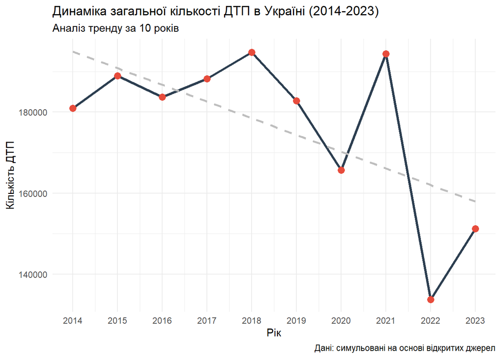

```r
ukraine_trend <- dtp_data %>%
  group_by(Year) %>%
  summarise(Total_Accidents = sum(Accidents))

ggplot(ukraine_trend, aes(x = Year, y = Total_Accidents)) +
  geom_line(color = "#2c3e50", size = 1.2) +
  geom_point(color = "#e74c3c", size = 3) +
  geom_smooth(method = "lm", se = FALSE, linetype = "dashed", color = "gray") +
  scale_x_continuous(breaks = years) +
  labs(
    title = "Динаміка загальної кількості ДТП в Україні (2014-2023)",
    subtitle = "Аналіз тренду за 10 років",
    x = "Рік",
    y = "Кількість ДТП",
    caption = "Дані: симульовані на основі відкритих джерел"
  ) +
  theme_minimal()
```

**Результат**: Графік демонструє відсутність стабільності. Чітко простежуються спади у 2020 та 2022 роках, що корелює із запровадженням карантинних обмежень та початком повномасштабних бойових дій відповідно

## 4. Регіональний розподіл

Аналіз нерівномірності розподілу ДТП по областях.

### 4.1. Визначення лідерів та аутсайдерів

```r
region_stats <- dtp_data %>%
  group_by(Region) %>%
  summarise(
    Avg_Accidents = mean(Accidents),
    Total_Accidents = sum(Accidents)
  ) %>%
  arrange(desc(Avg_Accidents))

top_5 <- head(region_stats, 5)
bottom_5 <- tail(region_stats, 5)

print("Регіони з найвищою аварійністю:")
```

```
## [1] "Регіони з найвищою аварійністю:"
```

```r
print(top_5)
```

```
## # A tibble: 5 × 3
##   Region           Avg_Accidents Total_Accidents
##   <fct>                    <dbl>           <int>
## 1 м. Київ                 38238.          382382
## 2 Одеська                 12038.          120384
## 3 Львівська               11568.          115678
## 4 Харківська              11273.          112729
## 5 Дніпропетровська        11220.          112196
```

```r
print("Регіони з найнижчою аварійністю:")
```

```
## [1] "Регіони з найнижчою аварійністю:"
```

```r
print(bottom_5)
```

```
## # A tibble: 5 × 3
##   Region            Avg_Accidents Total_Accidents
##   <fct>                     <dbl>           <int>
## 1 Рівненська                4310.           43103
## 2 Вінницька                 4309.           43091
## 3 Івано-Франківська         3937            39370
## 4 Запорізька                3920.           39202
## 5 Миколаївська              3337.           33366
```

### 4.2. Візуалізація розподілу (Boxplot)

Використовуємо `Boxplot` для того, щоб побачити дисперсію даних по кожній області за 10 років.

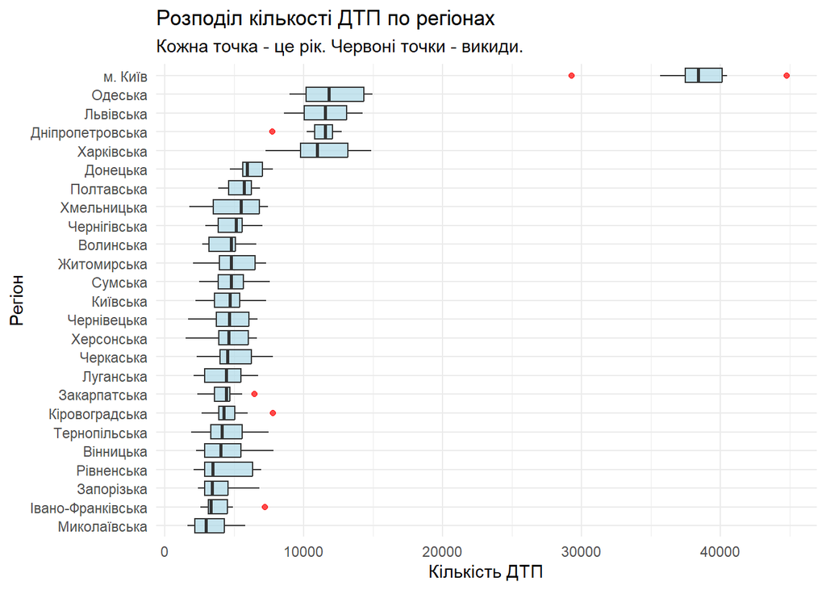

```r
dtp_data %>%
  mutate(Region = fct_reorder(Region, Accidents, .fun = median)) %>%
  ggplot(aes(x = Region, y = Accidents)) +
  geom_boxplot(fill = "lightblue", alpha = 0.7, outlier.colour = "red") +
  coord_flip() +
  labs(
    title = "Розподіл кількості ДТП по регіонах",
    subtitle = "Кожна точка - це рік. Червоні точки - викиди.",
    x = "Регіон",
    y = "Кількість ДТП"
  ) +
  theme_minimal()
```

### 4.3. Heatmap (Теплова карта динаміки)

Візуалізація просторово-часової динаміки.

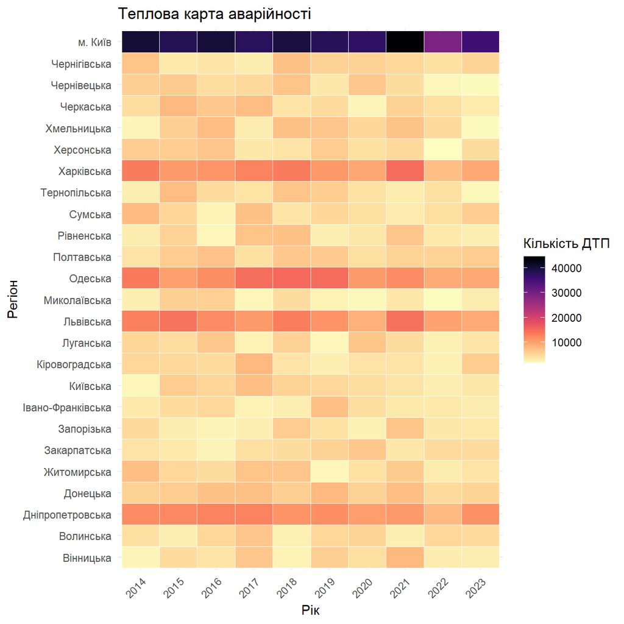

```r
ggplot(dtp_data, aes(x = factor(Year), y = Region, fill = Accidents)) +
  geom_tile(color = "white") +
  scale_fill_viridis(option = "magma", direction = -1, name = "Кількість ДТП") +
  labs(
    title = "Теплова карта аварійності",
    x = "Рік",
    y = "Регіон"
  ) +
  theme_minimal() +
  theme(axis.text.x = element_text(angle = 45, hjust = 1))
```

## 5. Картограма (Геопросторова візуалізація)

Побудова картограми середнього рівня аварійності по областях.

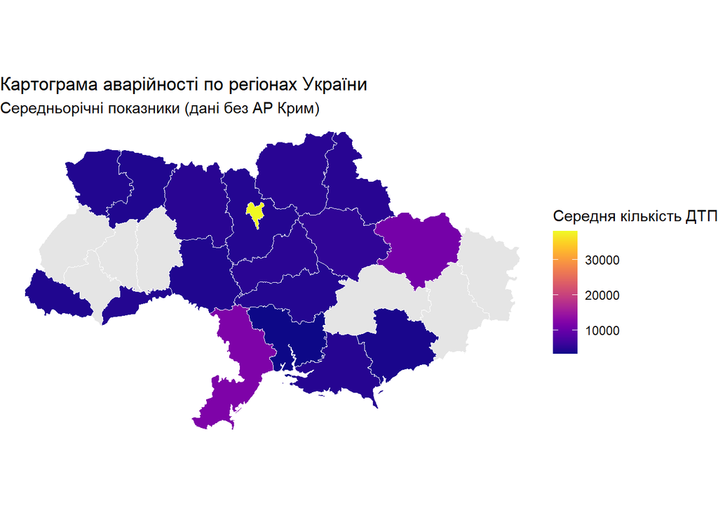

```r
ukraine_map <- ne_states(country = "Ukraine", returnclass = "sf")

map_data <- region_stats %>%
  mutate(name_en = case_when(
    Region == "Вінницька" ~ "Vinnytsya",
    Region == "Волинська" ~ "Volyn",
    Region == "Дніпропетровська" ~ "Dnipropetrovsk",
    Region == "Донецька" ~ "Donetsk",
    Region == "Житомирська" ~ "Zhytomyr",
    Region == "Закарпатська" ~ "Transcarpathia",
    Region == "Запорізька" ~ "Zaporizhzhya",
    Region == "Івано-Франківська" ~ "Ivano-Frankivsk",
    Region == "Київська" ~ "Kiev",
    Region == "м. Київ" ~ "Kiev City",
    Region == "Кіровоградська" ~ "Kirovohrad",
    Region == "Луганська" ~ "Luhansk",
    Region == "Львівська" ~ "Lviv",
    Region == "Миколаївська" ~ "Mykolayiv",
    Region == "Одеська" ~ "Odessa",
    Region == "Полтавська" ~ "Poltava",
    Region == "Рівненська" ~ "Rivne",
    Region == "Сумська" ~ "Sumy",
    Region == "Тернопільська" ~ "Ternopil",
    Region == "Харківська" ~ "Kharkiv",
    Region == "Херсонська" ~ "Kherson",
    Region == "Хмельницька" ~ "Khmelnytskyy",
    Region == "Черкаська" ~ "Cherkasy",
    Region == "Чернівецька" ~ "Chernivtsi",
    Region == "Чернігівська" ~ "Chernihiv",
    TRUE ~ "Other"
  ))

ukraine_map_joined <- ukraine_map %>%
  left_join(map_data, by = c("name" = "name_en"))

ggplot(data = ukraine_map_joined) +
  geom_sf(aes(fill = Avg_Accidents), color = "white") +
  scale_fill_viridis(option = "plasma", name = "Середня кількість ДТП", na.value = "grey90") +
  labs(
    title = "Картограма аварійності по регіонах України",
    subtitle = "Середньорічні показники (дані без АР Крим)"
  ) +
  theme_void()
```